# Clustering and visualization of scRNA-seq data with bubbletree

SK

This vignette introduces `bubbletree`, a transparent methodology for single cell RNA-seq data exploration based on well established methods clustering and visualization. We will demonstrate the functionality of `bubbletree` by analyzing two scRNA-seq datasets (case studies A and B), while also showing the user how to integrate `bubbletree` with existing pipelines for scRNA-seq analysis e.g. based on Seurat.

To run this vignette we need several R-packages. Load them now:

```r
source(file = "~/Rutil/Init_Rpack.R")
source(file = "~/Rutil/Graphics.R")
source(file = "~/Rutil/Stats.R")

# source(file = "src/ClusteringUtil.R")
source(file = "../bubbletree/R/util.R")
library(farver, lib.loc = "/usr/local/lib/R/site-library")

library(Seurat, lib.loc = lib.loc)
library(ggplot2, lib.loc = lib.loc)
library(reshape2, lib.loc = lib.loc)
library(parallel, lib.loc = lib.loc)
library(ggtree, lib.loc = lib.loc)
library(cluster, lib.loc = lib.loc)
library(ape, lib.loc = lib.loc)
library(org.Hs.eg.db, lib.loc = lib.loc)
library(bluster, lib.loc = lib.loc)
library(SummarizedExperiment, lib.loc = lib.loc)
```

# Case study A: 3,918 cells from 5 cancer cell lines [^1]

In this case study we will analyze scRNA-seq from 3918 cancer cells derived from 5 cell lines: H2228, H1975, HCC827, H838 and A549

Cell types (ground truth) were inferred for each cell on the basis of known genetic variation with demuxlet. We will use this simple dataset to demonstrate the advantages of quantitative scRNA-seq data exploration with `bubbletree` in combination with `Seurat` preprocessing.

Load the data and peroform some basic scRNA-seq data processing steps with Seurat:

```r
# Lets load the benchmark data
load(file = "raw_data/Tian_2019/sc_mixology-master/data/sincell_with_class_5cl.RData")


# We are only interested in the 10x data object 'sce_sc_10x_5cl_qc'
d <- sce_sc_10x_5cl_qc


# Remove the remaining objects
rm(sc_Celseq2_5cl_p1, sc_Celseq2_5cl_p2, sc_Celseq2_5cl_p3, sce_sc_10x_5cl_qc)


# Get the meta data for each cell
meta <- colData(d)[, c("cell_line", "cell_line_demuxlet", "demuxlet_cls")]


# Create Seurat object from the raw counts and append the meta data to it
d <- Seurat::CreateSeuratObject(counts = d@assays$data$counts)
# check if all cells are matched between d and meta
# table(rownames(d@meta.data) == meta@rownames)
d@meta.data <- cbind(d@meta.data, meta@listData)


# Preprocessing with Seurat: SCT transformation + PCA + UMAP
d <- SCTransform(object = d)
d <- RunPCA(object = d, npcs = 20, features = VariableFeatures(object = d))
d <- RunUMAP(d, dims = 1:20)
```

The generated 2D UMAP shown below (left panel) contains 5 to 8 clusters of cells. After we color-code the cells by their predicted cell lines (right panel) we see 5 clusters, with some substructure also visible within the cell lines. This is a toy dataset composed of distinct cell lines, which makes the 2D UMAP simple to interpret. In more realistic scenarios, such as analyses of scRNA-seq data from PBMCs, we typically see more complex 2D UMAPs composed of cell clusters that are not clearly separated. Furthermore, in these analyses we will not have ground truth, and cell lines or cell types will have to be inferred based on different marker genes.

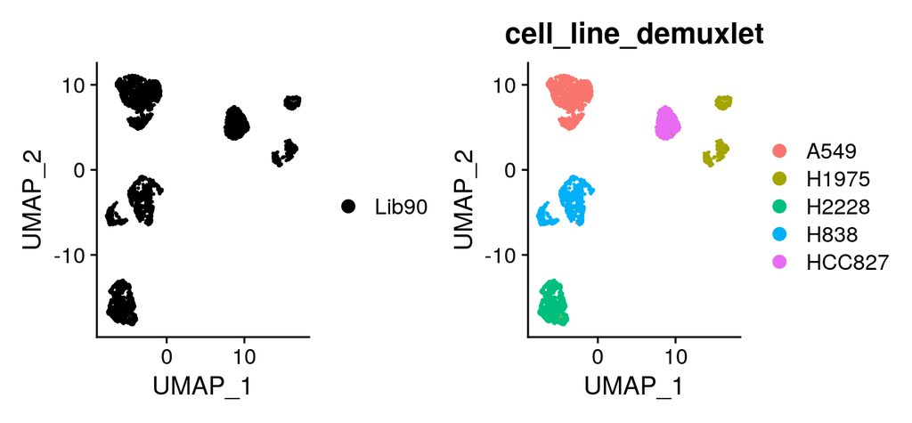

Now lets turn to `bubbletree`. As first input `bubbletree` uses matrix $A^{n\times f}$ which represents a low-dimensional feature space of the original scRNA-seq data, with $n$ rows as cells and $f$ columns as low- dimension features. We will use the PCA data generated by `Seurat` as $A$.

```r
# This is the main input of bubbletree
# -> matrix A with n=cells, f=features (e.g. from PCA)
A <- d@reductions$pca@cell.embeddings
```

`bubbletree` performs k-means clustering of $A$ to identify clusters of transcriptionally similar cells. Hence, our first goal is to determine `k`, i.e. the number of clusters in the data. This can be achieved with the function `get_kmeans_boot`.

`get_kmeans_boot` performs k-means clustering `B` times (bootstrapping iterations) for a number of `k` values specified by the parameter `ks`. For this we draw a subset of $A$ by sampling a proportion (`cv_clust_p`) of $A$ with replacement. `get_kmeans_boot` computes three metrics for each `k` and `B` which allow us to find the optimal `k`:

- silhouette index
- gap statistic
- within sum of squares (WSS) for elbow method

The remaining parameters of `get_kmeans_boot` are explained below:

- `n_start` and `iter_max`: used to tune k-means (see ?kmeans)
- `cores`: computer cores to be used
- `cv_gap_p` determines the proportion of cells to be used for the computation of the gap statistic . If you are running this function for relatively small samples (e.g. < 20,000 cells), then we suggest that you use default parameter values. For larger samples we have shown that low `cv_gap_p` (e.g. `cv_gap_p`=0.1 and `cv_clust_p`=0.66) produce reliable results. Small `B` (e.g. `B`=5) might be necessary to execute the function in a less than one hour for large datasets.

Lets run `get_kmeans_boot` now.

```r
b <- get_kmeans_boot(B = 20,
                     cv_clust_p = 1,
                     cv_gap_p = 1,
                     ks = 2:15,
                     x = A,
                     n_start = 10,
                     iter_max = 50,
                     cores = 20)
```

```
FALSE boot: 1  : 1) clustering, 2) silhouette, 3) gap-stat, 4) WSS.
FALSE boot: 2  : 1) clustering, 2) silhouette, 3) gap-stat, 4) WSS.
FALSE boot: 3  : 1) clustering, 2) silhouette, 3) gap-stat, 4) WSS.
FALSE boot: 4  : 1) clustering, 2) silhouette, 3) gap-stat, 4) WSS.
FALSE boot: 5  : 1) clustering, 2) silhouette, 3) gap-stat, 4) WSS.
FALSE boot: 6  : 1) clustering, 2) silhouette, 3) gap-stat, 4) WSS.
FALSE boot: 7  : 1) clustering, 2) silhouette, 3) gap-stat, 4) WSS.
FALSE boot: 8  : 1) clustering, 2) silhouette, 3) gap-stat, 4) WSS.
FALSE boot: 9  : 1) clustering, 2) silhouette, 3) gap-stat, 4) WSS.
FALSE boot: 10  : 1) clustering, 2) silhouette, 3) gap-stat, 4) WSS.
FALSE boot: 11  : 1) clustering, 2) silhouette, 3) gap-stat, 4) WSS.
FALSE boot: 12  : 1) clustering, 2) silhouette, 3) gap-stat, 4) WSS.
FALSE boot: 13  : 1) clustering, 2) silhouette, 3) gap-stat, 4) WSS.
FALSE boot: 14  : 1) clustering, 2) silhouette, 3) gap-stat, 4) WSS.
FALSE boot: 15  : 1) clustering, 2) silhouette, 3) gap-stat, 4) WSS.
FALSE boot: 16  : 1) clustering, 2) silhouette, 3) gap-stat, 4) WSS.
FALSE boot: 17  : 1) clustering, 2) silhouette, 3) gap-stat, 4) WSS.
FALSE boot: 18  : 1) clustering, 2) silhouette, 3) gap-stat, 4) WSS.
FALSE boot: 19  : 1) clustering, 2) silhouette, 3) gap-stat, 4) WSS.
FALSE boot: 20  : 1) clustering, 2) silhouette, 3) gap-stat, 4) WSS.
```

The results of `get_kmeans_boot` are shown below. Points in these plots are results from each bootstrap iteration. We used `B=20`, hence for each `k` we have 20 points.

`k` is is easily discernible from each of the three metrics (panels).

The silhouette index peaks around `k=5` (left panel) and for larger `k`s the silhouette index starts to drop and is numerically less stable. Hence, we can conclude that `k` values between 5 and 8 seem reasonable for this dataset, which is consistent with the 2D UMAP structure shown before. This conclusion is confirmed by the gap statistic (middle panel) and the elbow method based on WSS (right panel), i.e. we see a kinks around `k`=5 in the corresponding plots.

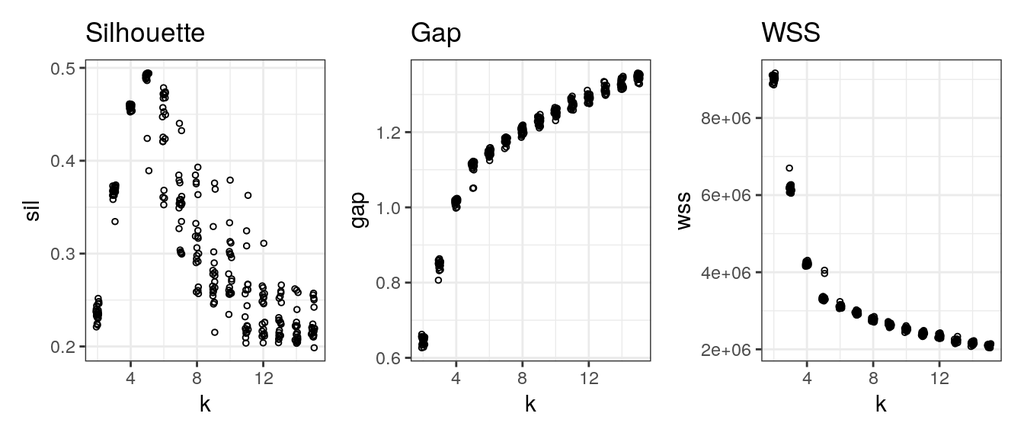

Lets start with the simplest model `k=5` and use `bubbletree` to perform clustering.

```r
# Perform clustering to get data for bubbletree
btd_k5 <- get_bubbletree_data(x = A,
                              k = 5,
                              seed = 1234,
                              cores = 1,
                              B = 1,
                              N_eff = 500)

# Generate bubbletree
bt <- get_bubbletree(btd = btd_k5)
```

The generated bubbletree has `k`=5 bubbles (clusters) shown as tree leaves. The radius of each bubble is scaled as function of the the number of cells that belong to the corresponding clusters. In addition to this, the bubbles are color-code in accordance with size, i.e. dark bubbles are typically large and have many cells, while bright bubbles are typically small and contain few cells.

Bubble 3 is the largest (and darkest) one in the `bubbletree` as and contains 1,253 cells ($\approx$ 32% of all cells in the dataset), while bubble 5 is the smallest one (and brightest) and contains only 436 cells ($\approx$ 11% of all cells in the dataset).

The average distances between a pair of bubbles are represented by the sums of branch length in the dendrogram. For instance, the average Euclidean distance between cluster 5 and 4 is approximately (45 - 7) * 2 = 76, while the average Euclidean distance between 5 and 2 is approximately (45 - 0) * 2 = 90.

We see similar distances between the pairs of bubbles, and low degree of structure in the dendrogram. This makes sense as the data is composed of cells derived from from 5 distinct cell lines. We will see in case study B, in which we will inspect real dataset of PBMCs, that cell types in real datasets are structured, i.e. we will see branches in the dendrogram formed by transcriptionally similar groups of cells (e.g. CD4 and CD8 T-cells).

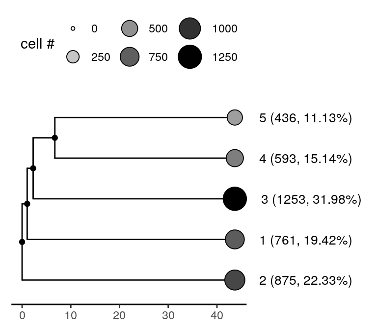

```r
bt$tree
```

How can we verify that this clustering is sensible?

For this `bubbletree` offers a rich set of annotation add-ons. For instance, for each cell we have the predicted cell types. We can generate a tile-plot showing us the proportions of each cell type in the five bubbles.

For categorical data we use the function `get_annotation_tiles_char`:

```r
w1 <- get_annotation_tiles_char(k = btd_k5$km$cluster,
                                a = d@meta.data$cell_line_demuxlet,
                                tree_meta = bt$tree_meta,
                                integrate_over_clusters = F)
```

`bubbletree` uses the R-package `patchwork` to combine plots. Lets merge the `bubbletree` with the newly generated annotations:

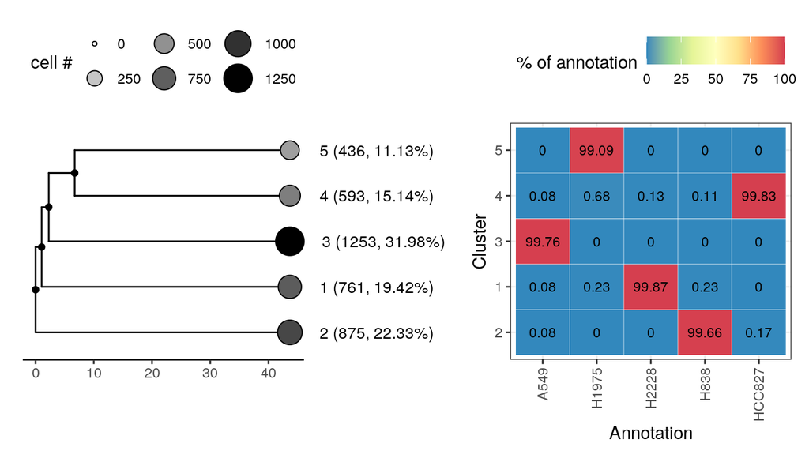

```r
(bt$tree|w1$w)+patchwork::plot_layout(ncol = 2, widths = c(1, 1))
```

This plot tells us that cells with each annotation are exclusively (>99%) found in a common bubble, i.e. columns integrate to 100%. For instance, 99.76% of the A549 cells are found in bubble 3, 99.09% of the H1975 cells are found in bubble 5. Few cells from a given cell type are mixed in different bubbles. This mixing is also present in the 2D UMAP, however, doe to the heavy overplotting they are not visible. Our approach is more transparent in this sense, and show in a quantitative way the clustering output.

We might also be curious to check the homogeneity of individual bubbles. For this we will draw a similar plot but make sure that the rows integrate to 100%.

The annotation plot below informs us that 100% of the cells in bubble 5 belong to cell type H1975. About 0.17% of the 593 cells in bubble 4 belong to cell A549. This is equal to 0.17/100*593 = 1 cell, while the majority of cells 98.99 belong to cell HCC827. Hence, we see quite high homogeneity within the bubbles.

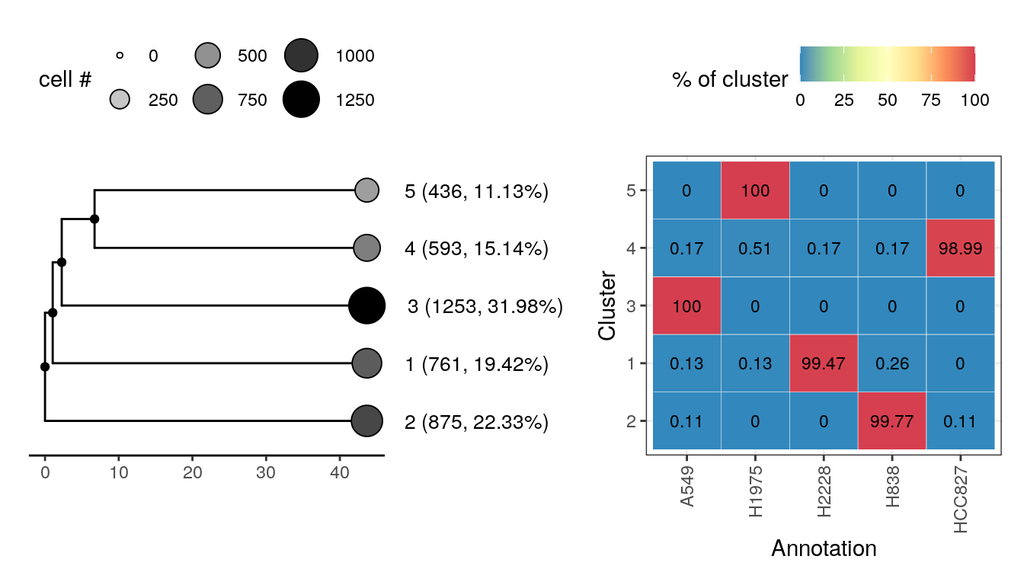

```r
w2 <- get_annotation_tiles_char(k = btd_k5$km$cluster,
                               a = d@meta.data$cell_line_demuxlet,
                               tree_meta = bt$tree_meta,
                               integrate_over_clusters = TRUE) # <- changed

(bt$tree|w2$w)+patchwork::plot_layout(ncol = 2, widths = c(1, 1))
```

`bubbletree` implements add-ons for visualization of numeric cell properties, such as gene expression. Lets visualize the expression of five genes, which are markers of the five cancer cell lines. We can visualize this numeric data in two ways. First, we can show the average marker gene expression in each bubble for each marker as a tile plot with `get_annotation_tiles_num`.

Lets invoke this function now.

```r
# First we need to select gene expressions for each cell and
# also for five marker genes
as <- as.matrix(t(d@assays$SCT@data[
  rownames(d@assays$SCT@data) %in%
    c("ALDH1A1", "OS9", "PEG10", "S100A9", "SLPI"), ]))

# 'as' is a matrix with n=rows for cells and a=columns for
# annotations (genes). The column names will be shown in
# the plot.

# We will order the columns in 'as' in the same way we want
# them to be plotted. These genes are markers for: A549,
# HCC827, H1975, H2228 and H838
as <- as[, c("ALDH1A1", "OS9", "PEG10", "S100A9", "SLPI")]
```

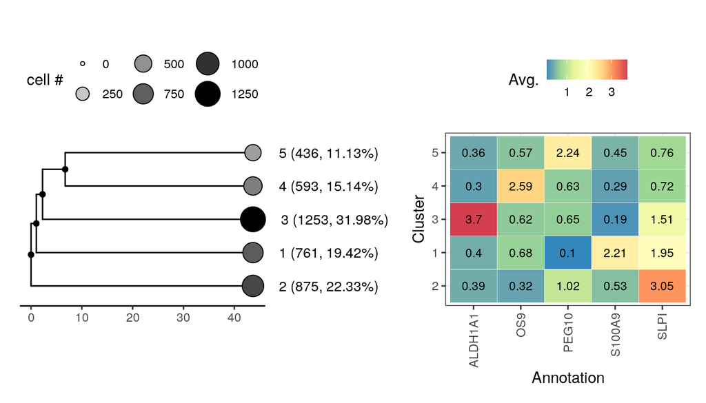

```r
# This function build the nummeric annotations plot
w3 <- get_annotation_tiles_num(k = btd_k5$km$cluster,
                               as = as,
                               tree_meta = bt$tree_meta,
                               plot_title = "")

# Plot
(bt$tree|w3$w)+patchwork::plot_layout(widths = c(1, 1))
```

Second, we can visualize the distribution of each marker gene in each bubble using violin plots with `get_annotation_violins`. This function uses the same input as `get_annotation_tiles_num`.

Lets invoke this function now.

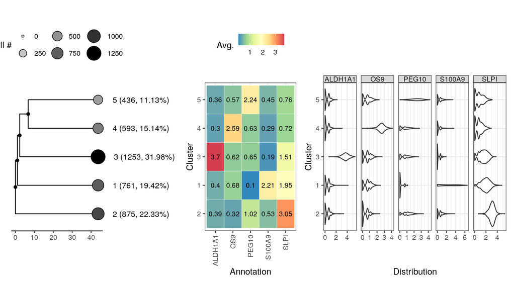

```r
w4 <- get_annotation_violins(k = btd_k5$km$cluster,
                             as = as,
                             tree_meta = bt$tree_meta,
                             plot_title = "",
                             scales = 'free_x')

(bt$tree|w3$w|w4$w)+patchwork::plot_layout(widths = c(1, 1, 2))
```

`bubbletree` is intended to promote transparent analysis of scRNA-seq. The user of `bubbletree` is encouraged to try different values of `k` and at each stage perform bubble/cluster annotation. From this, the user has to provide answer to the following questions:

1. is the selected `k` biologically justifiable?
2. is the resulting bubbletree structure biologically meaningful?
3. if we increased `k`, can we explain biologically the newly created bubbles using annotation?

We will clarify this point in **Case study B**.

# Case study B: 53,000 PBMCs from 8 healthy donors [^2][^3]

In this case study we will analyze scRNA-seq of approximately 53,000 PBMCs derived from 8 healthy donors. This represents a more realistic dataset compared to the toy example presented as part of case study A.

In addition to gene expression, this data reports for each cell a cell type predictions at three levels of resolution (l1, l2 and l3), which can be used to validate the performance of the clustering approach.

In essence, we will perform the same steps as in case study A:

1. determine `k`
2. build a bubbletree
3. annotate the bubbletree with numeric and categorical data
4. criticize the results, and if necessary modify `k` and go back to 2.

The data for this case study has already been preprocessed with `Seurat`. SCT transformation was used to normalize the gene expressions, followed by principal component analysis for dimensionality reduction. 50 low-space features have been extracted and used to generate a 2D UMAP.

Lets load the data.

```r
# To get the data used in this case study do the following steps:
# 1. download reference data from vignette:
# ttps://satijalab.org/seurat/articles/multimodal_reference_mapping.html
# 2. load SeuratDistk
# library(SeuratDisk, lib.loc = lib.loc)
# 3. subset data at time=0
# d_t0 <- subset(x = d, subset = time == 0)
# d <- LoadH5Seurat("~/BubbleMap/raw_data/Hao_2021/pbmc_multimodal.h5seurat")
# save(d_t0, file = "Hao_2021_t0.RData")
```

```r
d_t0 <- get(load(file = "raw_data/Hao_2021_t0.RData"))
```

We can enumerate the number of cells per donor and predicted cell type

```r
table(d_t0@meta.data$celltype.l1,
      d_t0@meta.data$donor)
```

```
FALSE
FALSE             P1   P2   P3   P4   P5   P6   P7   P8
FALSE   B        240  470  373  410  544  732  987  394
FALSE   CD4 T   2198 1921 1422 1524  897 1062 1259 2052
FALSE   CD8 T   1155 1140  527  913 1160  356 1223 1648
FALSE   DC       128   93   72  114  216   95  384  123
FALSE   Mono    1914 1330 1188 1749 2777 2773 3792 3193
FALSE   NK       495  555  891  119  865  796  998 1075
FALSE   other    219   92   67   58  221  162   92  101
FALSE   other T   94  377  158  420  340  117  174  330
```

The 2D UMAP looks as follows:

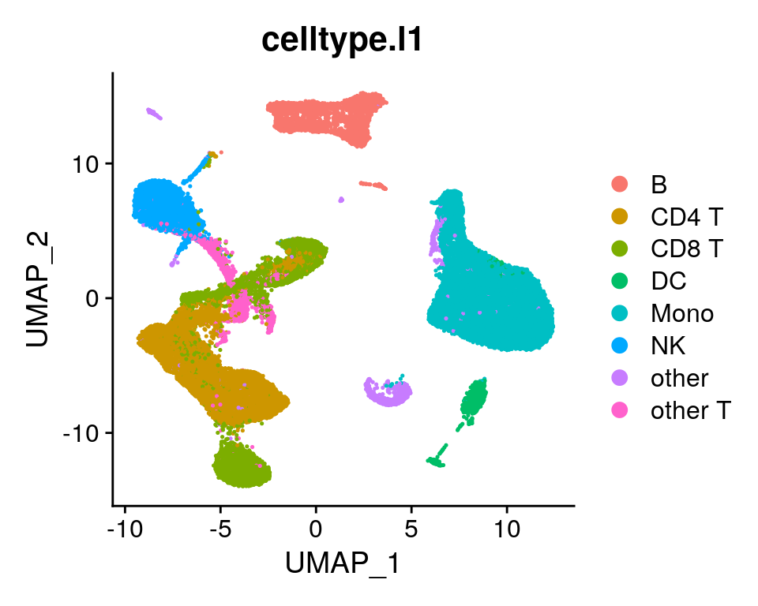

```r
# Lets show the generated 2D UMAP
UMAPPlot(object = d_t0,
         reduction = "umap",
         group.by = 'celltype.l1',
         pt.size = 0.25)
```

Now that the UMAP shows more than 50,000 cells we start to see the challenges associated with this approach:

- massive overplotting
- qualitative
- unstable: rotation, change in cell order affects interpretation
- scalability issue: limited number of annotations/colors/cells can be used

Now lets turn to `bubbletree`. As earlier, our first goal is to determine `k` for the clustering algorithm with the function `get_kmeans_boot`. Notice the modified function parameters for faster execution:

```r
# This is the main input of bubbletree
# -> matrix A with n=cells, f=features (from PCA)
A <- d_t0@reductions$pca@cell.embeddings

# Determine appropriate number of clusters (k)
b <- get_kmeans_boot(B = 20,
                     cv_clust_p = 0.66, # use 66% for clustering
                     cv_gap_p = 0.25, # use 25% for gap stat. comp.
                     ks = seq(from = 3, to = 42, by = 3),
                     x = A,
                     n_start = 10,
                     iter_max = 50,
                     cores = 20)
```

```
FALSE boot: 1  : 1) clustering, 2) silhouette, 3) gap-stat, 4) WSS.
FALSE boot: 2  : 1) clustering, 2) silhouette, 3) gap-stat, 4) WSS.
FALSE boot: 3  : 1) clustering, 2) silhouette, 3) gap-stat, 4) WSS.
FALSE boot: 4  : 1) clustering, 2) silhouette, 3) gap-stat, 4) WSS.
FALSE boot: 5  : 1) clustering, 2) silhouette, 3) gap-stat, 4) WSS.
FALSE boot: 6  : 1) clustering, 2) silhouette, 3) gap-stat, 4) WSS.
FALSE boot: 7  : 1) clustering, 2) silhouette, 3) gap-stat, 4) WSS.
FALSE boot: 8  : 1) clustering, 2) silhouette, 3) gap-stat, 4) WSS.
FALSE boot: 9  : 1) clustering, 2) silhouette, 3) gap-stat, 4) WSS.
FALSE boot: 10  : 1) clustering, 2) silhouette, 3) gap-stat, 4) WSS.
FALSE boot: 11  : 1) clustering, 2) silhouette, 3) gap-stat, 4) WSS.
FALSE boot: 12  : 1) clustering, 2) silhouette, 3) gap-stat, 4) WSS.
FALSE boot: 13  : 1) clustering, 2) silhouette, 3) gap-stat, 4) WSS.
FALSE boot: 14  : 1) clustering, 2) silhouette, 3) gap-stat, 4) WSS.
FALSE boot: 15  : 1) clustering, 2) silhouette, 3) gap-stat, 4) WSS.
FALSE boot: 16  : 1) clustering, 2) silhouette, 3) gap-stat, 4) WSS.
FALSE boot: 17  : 1) clustering, 2) silhouette, 3) gap-stat, 4) WSS.
FALSE boot: 18  : 1) clustering, 2) silhouette, 3) gap-stat, 4) WSS.
FALSE boot: 19  : 1) clustering, 2) silhouette, 3) gap-stat, 4) WSS.
FALSE boot: 20  : 1) clustering, 2) silhouette, 3) gap-stat, 4) WSS.
```

We see high silhouette index values between `k`=6 and `k`=9. This makes biological sense as PBMCs are typically composed of several major cell types as shown in the UMAP above. Using the gap statistic or WSS does not yield easily discernable `k`, however, both metrics appear to slowly flatten as `k` increases beyond 20. Hence, we can use these metrics to determine an upper bound for useful `k`.

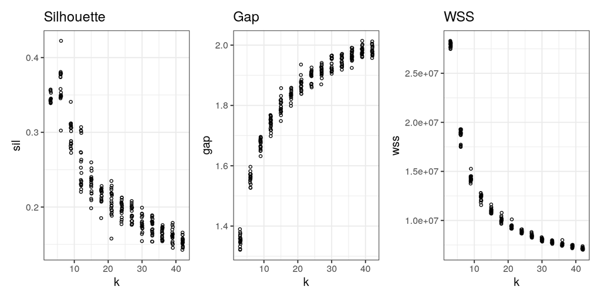

```r
ggplot()+
  geom_jitter(data = b$sil_stats, aes(x = k, y = sil),
             size = 1, shape = 21, width = 0.1, height = 0)+
  ggtitle(label = "Silhouette")|ggplot()+
  geom_jitter(data = b$gap_stats, aes(x = k, y = gap),
             size = 1, shape = 21, width = 0.1, height = 0)+
  ggtitle(label = "Gap")|ggplot()+
  geom_jitter(data = b$wss_stats, aes(x = k, y = wss),
             size = 1, shape = 21, width = 0.1, height = 0)+
  ggtitle(label = "WSS")
```

Lets start with `k`=6 and use `get_bubbletree_data` to perform clustering.

```r
btd_k6 <- get_bubbletree_data(x = A,
                              k = 6,
                              n_start = 100,
                              iter_max = 100,
                              seed = 432,
                              cores = 1,
                              B = 1,
                              N_eff = 500)
```

Next, we use `get_bubbletree` to compute the bubbletree.

Interesting, now we see some structure in the dendrogram, i.e. bubbles 1 and 4 and 5, 3 and 6 form two distinct branches, while the smalles bubble 2 is an outgroup.

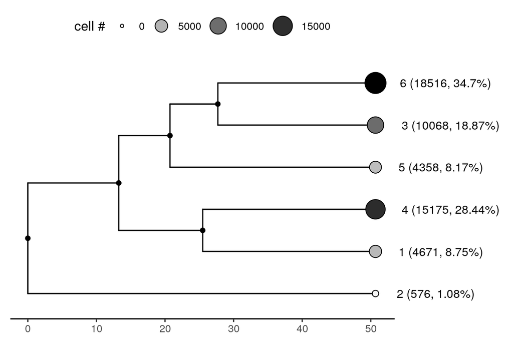

```r
bt <- get_bubbletree(btd = btd_k6)
bt$tree
```

Does this make biological sense? Lets confirm this by visualizing the predicted cell type annotations and summarize the results:

- branch with bubble 6 and 3:
  - about 100% of CD4 T-cells are found in bubble 6 and 3
  - the branch is also enriched with CD8 T-cells, NK cells, other T cells.
  - bubble 6 also contains 21% of the cells predicted as ‘other’
  - in summary: this branch contains cells related to T-cells
- bubble 5 is related to bubbles 6 and 3:
  - this bubble is enriched with B-cells
  - it also contains 23% of DCs $\rightarrow$ this is one indication that we should try building bubble trees with higher `k` values.
  - in summary: the branch connecting bubbles 6, 3 and 5 is enriched with lymphocytes.
- branch with bubbles 4 and 1:
  - this branch is enriched with two related cell types, i.e. monocytes (Mono) and dendritic cells (DCs)
  - it also contains about 22% of the cells predicted as ‘other’
- outgroup bubble 2 is enriched with cells predicted as ‘other’

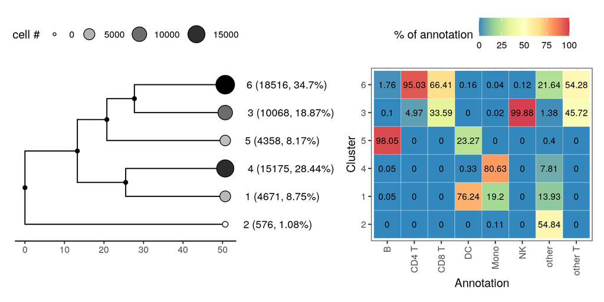

```r
# cell type annotations (level 1)
a <- d_t0@meta.data$celltype.l1

# create tile plot
w <- get_annotation_tiles_char(k = btd_k6$km$cluster,
                               a = a,
                               tree_meta = bt$tree_meta,
                               integrate_over_clusters = F)

(bt$tree|w$w)+patchwork::plot_layout(ncol = 2, widths = c(1, 1))
```

Lets also try setting `k`=9. The effect of this is finer structure in the different branches. For instance, NK cells (bubble 8) are now separated from CD4 and CD8 T-cells (bubbles 1 and 5), and B-cells are found in bubble 6. We also see finer structure in the branch of monocytes and DCs.

```r
btd_k9 <- get_bubbletree_data(x = A,
                           k = 9,
                           n_start = 100,
                           iter_max = 100,
                           seed = 432,
                           cores = 1,
                           B = 1,
                           N_eff = 500)
```

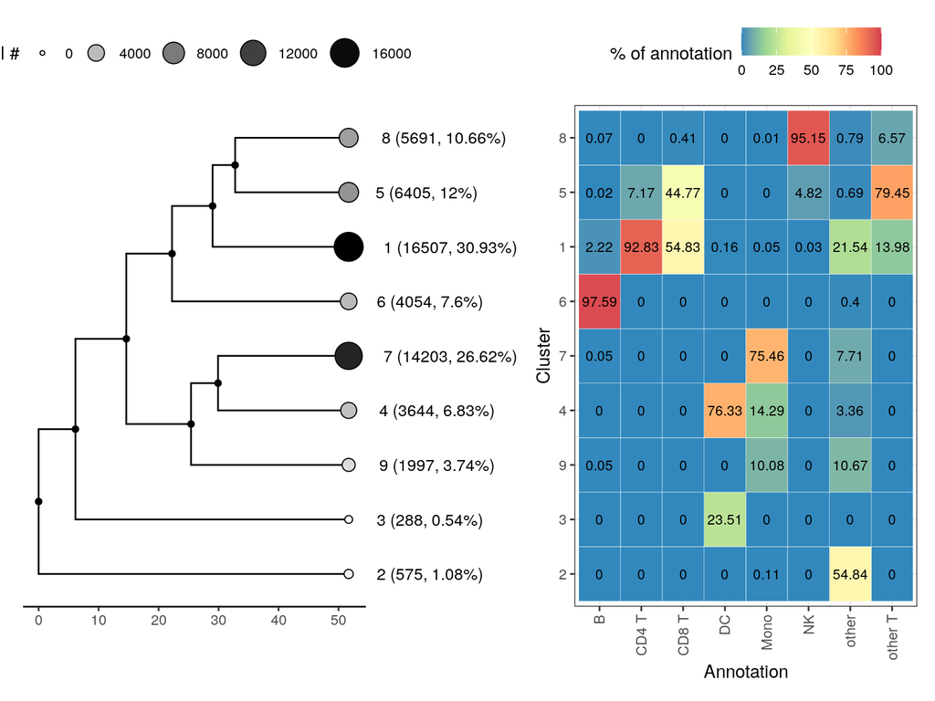

```r
bt <- get_bubbletree(btd = btd_k9)

# cell type annotations (level 1)
a <- d_t0@meta.data$celltype.l1

# create tile plot
w <- get_annotation_tiles_char(k = btd_k9$km$cluster,
                               a = a,
                               tree_meta = bt$tree_meta,
                               integrate_over_clusters = F)

(bt$tree|w$w)+patchwork::plot_layout(ncol = 2, widths = c(1, 1))
```

We can also use a finer (level 2) cell type prediction to validate our clustering. The fact that bubble 1 contains many different cell types indicates that even higher `k` values can be used. In the next plot we show the bubbletree for `k`=20, the upper bound for `k` determined above.

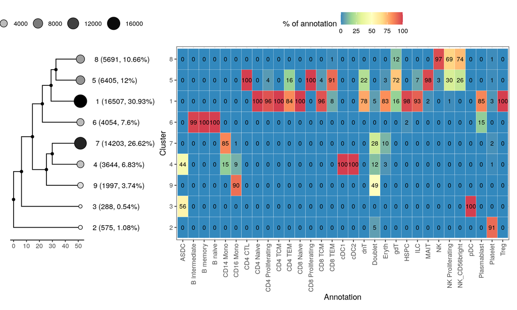

```r
bt <- get_bubbletree(btd = btd_k9)

# cell type annotations (level 2)
a <- d_t0@meta.data$celltype.l2

# create tile plot
w <- get_annotation_tiles_char(k = btd_k9$km$cluster,
                               a = a,
                               tree_meta = bt$tree_meta,
                               integrate_over_clusters = F,
                               round_digits = 0)

(bt$tree|w$w)+patchwork::plot_layout(ncol = 2, widths = c(2, 9))
```

With this segmentation most cell types occupy their own tile in the tile plot. Hence, using a `k` higher than 20 is not advisable. Furthermore, the cell type profiles of bubbles 16, 3 and 20 in the tile plot and in the bubbletree are barely distinguishable, which suggests that a `k` value lower than 20 would suffice to capture cell types at this resolution.

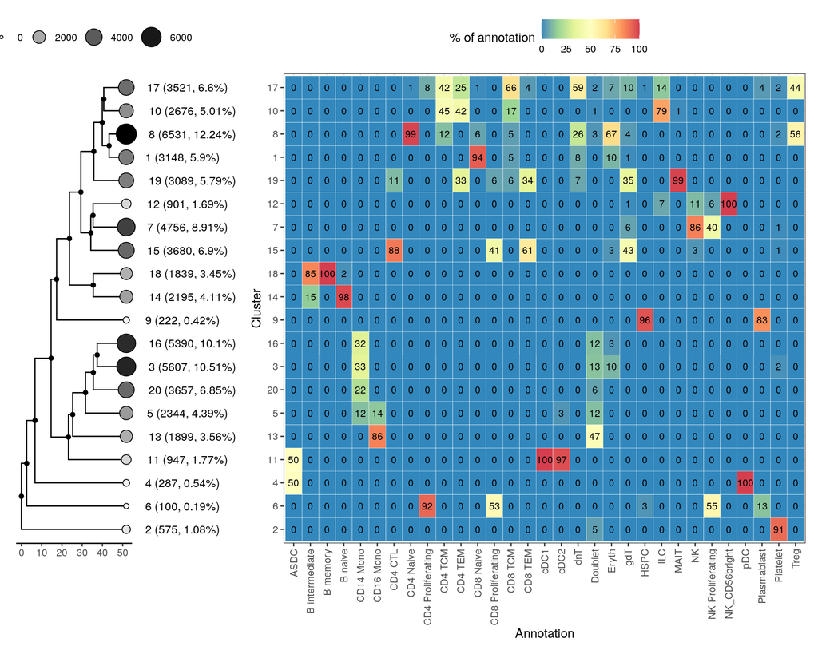

```r
btd_k20 <- get_bubbletree_data(x = A,
                               k = 20,
                               n_start = 100,
                               iter_max = 100,
                               N_eff = 500,
                               seed = 432,
                               cores = 1,
                               B = 1)

bt <- get_bubbletree(btd = btd_k20)

# cell type annotations (level 2)
a <- d_t0@meta.data$celltype.l2

# create tile plot
w <- get_annotation_tiles_char(k = btd_k20$km$cluster,
                               a = a,
                               tree_meta = bt$tree_meta,
                               integrate_over_clusters = F,
                               round_digits = 0)

(bt$tree|w$w)+patchwork::plot_layout(ncol = 2, widths = c(2, 9))
```

Gene expression annotations can also be integrated to better explain the clustering structure of the `bubbletree`. Lets integrate some marker genes:

- GNLY, NKG7: NK cells
- IL7R: CD4 T cells
- CD8A: CD8 T cells
- MS4A1: B cells
- CD14, LYZ: CD14+ Monocytes
- FCGR3A, MS4A7: FCGR3A+ Monocytes
- FCER1A, CST3: Dendritic Cells
- PPBP: Megakaryocytes

```r
# First we need to select gene expressions for each cell and
# also for five marker genes
as <- as.matrix(t(d_t0@assays$SCT@data[
  rownames(d_t0@assays$SCT@data) %in%
    c("IL7R",
      "CD14", "LYZ",
      "MS4A1",
      "CD8A",
      "GNLY", "NKG7",
      "FCGR3A", "MS4A7",
      "FCER1A", "CST3",
      "PPBP"), ]))

# 'as' is a matrix with n=rows for cells and a=columns for
# annotations (genes). The column names will be shown in
# the plot.
```

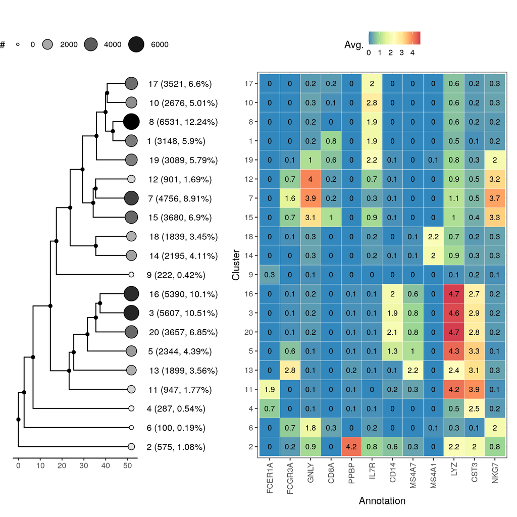

```r
# This function build the nummeric annotations plot
w1 <- get_annotation_tiles_num(k = btd_k20$km$cluster,
                               as = as,
                               tree_meta = bt$tree_meta,
                               plot_title = "",
                               round_digits = 1)

# Plot
(bt$tree|w1$w)+patchwork::plot_layout(widths = c(1, 2))
```

Second, we can visualize the distribution of each marker gene in each bubble using violin plots with `get_annotation_violins`. This function uses the same input as `get_annotation_tiles_num`.

Lets invoke this function now.

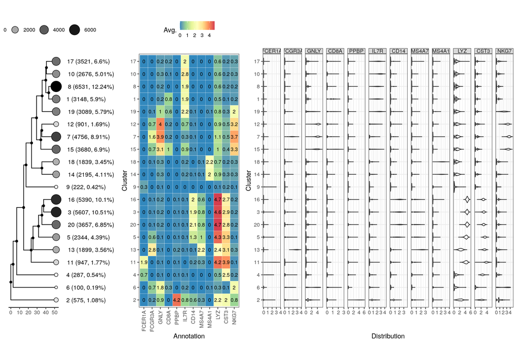

```r
w2 <- get_annotation_violins(k = btd_k20$km$cluster,
                             as = as,
                             tree_meta = bt$tree_meta,
                             plot_title = "",
                             scales = 'free_x')

(bt$tree|w1$w|w2$w)+patchwork::plot_layout(widths = c(1, 2, 5))
```

[^1]: Tian, Luyi, et al. “Benchmarking single cell RNA-sequencing analysis pipelines using mixture control experiments.” Nature methods 16.6 (2019): 479-487.
[^2]: Hao, Yuhan, et al. “Integrated analysis of multimodal single-cell data.” Cell 184.13 (2021): 3573-3587.
[^3]: https://satijalab.org/seurat/articles/multimodal_reference_mapping.html